# The grammar of tables in python (pandas) and R (gt)

Author

Karina Bartolomé

# Introduction

The **{ggplot2} 📦**[^1]is one of the most widely used packages for data visualization in R. It is based on **Grammar of Graphics**, Wilkinson (2012), and allows you to generate plots using layers. On the other hand, the **Grammar of Tables {gt}**📦 [^2] is used to generate tables with a structure similar to that of {ggplot2}, using layers. Both approaches can be combined with tables that include graphics. In this case, I put together an example with data provided by the open data portal of the Autonomous City of Buenos Aires. The example is replicated with **{pandas}**📦[^3].

This post is a short version of the following posts:

- **gt**: [Uso del subte en la Ciudad Autónoma de Buenos Aires](https://karbartolome-blog.netlify.app/posts/tablas-subte/)
- **pandas**: [Formato en tablas Pandas](https://karbartolome-blog.netlify.app/posts/tablas-pandas/)

The code below shows how to generate the following **tables**:

**Comparisson**

[figure not shown]

Gt table (R)

[figure not shown]

Pandas table (python)

**R table**

[figure not shown]

**Python table**

[figure not shown]

**Comparisson part 2**

[figure not shown]

# 1️⃣ Packages

The **required packages** 📦are loaded. Both in R and in python.

**R**

```r
library(tidyverse)
library(lubridate)
library(circular)
library(gt)
library(gtExtras)
library(gtsummary)
library(reshape)
library(sf)
library(stringr)
library(circular)
library(webshot2)
library(reticulate)
conflicted::conflict_prefer("filter", "dplyr")
conflicted::conflict_prefer("webshot", "webshot2")
conflicted::conflict_prefer("select", "dplyr")
options(scipen=999)
```

**Python**

A **conda environment** is created for this project, with python 3.9.5:

```r
reticulate::conda_create(envname='tables', python_version="3.9.5")
```

The required **python packages** 📦 are installed via conda-forge with **reticulate**:

```r
reticulate::conda_install(envname='tables',
                          packages='numpy', channel = 'conda-forge')

reticulate::conda_install(envname='tables',
                          packages='pandas', channel = 'conda-forge')

reticulate::conda_install(envname = 'tables',
                          packages='matplotlib=3.5.3', channel='conda-forge')

reticulate::conda_install(envname = 'tables',
                          packages='plotnine', channel='conda-forge')

reticulate::conda_install(envname = 'tables',
                          packages='jinja2', channel='conda-forge')

reticulate::conda_install(envname = 'tables',
                          packages='seaborn', channel='conda-forge')

reticulate::conda_install(envname = 'tables',
                          packages='geopandas', channel='conda-forge')

reticulate::conda_install(envname = 'tables',
                          packages='ipykernel', channel='conda-forge')
```

The conda environment is defined for this script:

```r
reticulate::use_condaenv(
  condaenv = 'tables',
  required = TRUE
)
```

Imports:

```python
import numpy as np
import pandas as pd
import geopandas as gpd
from io import BytesIO
import base64
from IPython.core.display import HTML
from plotnine import *
import seaborn as sns
import matplotlib.pyplot as plt
from mizani.formatters import date_format
from mizani.breaks import date_breaks
from scipy.stats import circmean
import pprint
import warnings
warnings.filterwarnings("ignore")
```

# 2️⃣ Data

Data from **subway trips in Buenos Aires, Argentina**, is used. The period of November 2021 was considered, taking the period of October 2021 to show the percentage variation. The data is loaded with python. Through the **{reticulate} package** 📦 it will be used with R.

```python
base_url = 'https://cdn.buenosaires.gob.ar/datosabiertos/datasets'
dataset  = 'sbase/subte-viajes-molinetes'

colors = {
  'A':'#18cccc',
  'B':'#eb0909',
  'C':'#233aa8',
  'D':'#02db2e',
  'E':'#c618cc',
  'H':'#ffdd00'
}

def read_data(url, dataset, file):

  path = f'{url}/{dataset}/{file}'

  df_ = (pd.read_csv(path, delimiter=';')

    # Remove useless data
    .query('~FECHA.isna()', engine='python')

    # Columns rename
    .rename(str.lower, axis='columns')
    .rename({
      'linea':'line',
      'desde':'hour',
      'fecha':'date',
      'estacion':'station'
    },axis=1)

    # Transformations
    .assign(
      line = lambda x: [i.replace('Linea','') for i in x['line']],
      date = lambda x: pd.to_datetime(x['date'],format='%d/%m/%Y'),
      color = lambda x: x['line'].replace(colors)
    )
    # Selected columns
    [['line', 'color', 'date', 'hour', 'station', 'pax_total']]
  )

  return(df_)

df = read_data(url=base_url, dataset=dataset, file='molinetes_112021.csv')
df_oct = read_data(url=base_url,dataset=dataset, file='molinetes_102021.csv')
```

Some stations information is also loaded:

```python
df_stations = (pd.read_csv('data/stations.csv')
  .rename({'linea':'line', 'estacion':'station'}, axis=1)
)
```

Number of passengers per station:

```python
rename_stations = {
      'Flores': 'San Jose De Flores',
      'Saenz Peña ': 'Saenz Peña',
      'Callao.b': 'Callao',
      'Retiro E': 'Retiro',
      'Independencia.h': 'Independencia',
      'Pueyrredon.d': 'Pueyrredon',
      'General Belgrano':'Belgrano',
      'Rosas': 'Juan Manuel De Rosas',
      'Patricios': 'Parque Patricios',
      'Mariano Moreno': 'Moreno'
}

df_passengers_station = (df
  .groupby(['line','color','station'], as_index=False)
  .agg(pax_total = ('pax_total','sum'))
  .assign(station = lambda x: x['station'].str.title())
  .replace(rename_stations)
  .merge(df_stations, on=['line','station'])
)
```

**Spatial data**

Geojson data from the city of Buenos Aires is loaded, in this case, both in R and python:

**R**

```r
base_url = 'http://cdn.buenosaires.gob.ar/datosabiertos/datasets/barrios/'
url = paste0(base_url, 'barrios.geojson')

map_caba <- st_read(url, quiet = TRUE) %>%
  mutate(barrio=str_to_title(BARRIO))
```

**Python**

```python
map_caba = gpd.read_file(r.url)
```

# 3️⃣Table

## Style and parameters definitions

Some aspects are defined in python:

```python
custom_style = [
  {'selector':"caption",
   'props':[("text-align", "left"),
            ("font-size", "135%"),
            ("font-weight", "bold")]},
  {'selector':'th',
   "props":  'text-align : center; background-color: white; color: black; font-size: 18; border-bottom: 1pt solid lightgrey'},
  {"selector": "",
   "props": [("border", "1px solid lightgrey")]}
]

title ='A summary of the use of the subway in the city of Buenos Aires, Argentina'
subtitle = 'Analysis period: November 2021'

source = "<br>Own elaboration based on data from the Open Data Portal from the city of Buenos Aires</br>"

footer_map = "% of passengers per station in relation to the total number of passengers on that line. For the cuts, the quantiles of the distribution were used. It is observed that Line C presented a very high use in the headwaters, while in the rest of the lines the use was more distributed."

footer_variation = "% Variation in relation to October 2021."

footer_clock = "The color line represents the mean hour, considering the circular distribution of the hour variable."

footer_moments_day = "Percentage per line: Morning = 5 a 11 hs, Afternoon = 12 a 17 hs, Night = 18 a 23 hs"
```

## Functions definition

### Images

A function to map a .jpg image with a column of a dataframe:

```python
def map_line_img(i):
    path = f'images/{i.lower()}.jpg'
    return '<img src="'+ path + '" width="25" >'
```

### Line plot

The evolution of passengers per day is included in the tables based on a line plot. Here, some functions are defined to generate these plots.

**R**

```r
fig_evol_pax_total <- function(.line, .color){
  py$df %>%
    filter(line == .line) %>%
    group_by(date) %>%
    summarise(n = sum(pax_total)) %>%
    ggplot(aes(x = date, y = n)) +
    geom_line(color = 'grey', size = 2.5) +
    geom_line(color = .color, size = 1.5) +
    scale_y_continuous(
      labels = scales::unit_format(unit = "K", scale = 1e-3)
    ) +
    labs(x = '', y = 'Passengers') +
    theme_minimal() +
    theme(
      text = element_text(size = 30),
      axis.title.y = element_text(color = 'grey'),
      panel.grid = element_blank()
    )
}
```

**Python**

```python
def fig_evol_pax_total(i):

    data_line=df.query("line==@i")

    color = data_line.color.max()

    data_line=(data_line
      .groupby('date', as_index=False)
      .pax_total
      .sum()
    )

    p = (ggplot(
          data = data_line,
          mapping = aes(x='date', y='pax_total',group=1)
        ) +
        geom_line(color=color)+
        theme_minimal()+
        labs(x='',y='N')+
        scale_x_datetime(
          labels = date_format("%Y-%m"),
          breaks=date_breaks('7 days')
        )+
        labs(x = '', y = '') +
        theme_void()+
        theme(
          panel_background= element_rect(fill=None),
          plot_background = element_rect(fill=None),
          text=element_text(size=7),
          axis_text_x=element_text(vjust=-0.5)
        )
    )
    return p

def plotnine2html(p,i, width=4, height=2):

    figfile = BytesIO()
    p.save(figfile, format='png', width=width, height=height, units='in')
    figfile.seek(0)
    figdata_png = base64.b64encode(figfile.getvalue()).decode()
    imgstr = f'<img src="data:…" />'

    return imgstr

def map_plot_evol(i):
    fig = fig_evol_pax_total(i)
    return plotnine2html(fig,i)
```

### Map

Some functions are defined in order to generate the maps in the tables.

**R**

```r
fig_map <- function(.df, .line){
   temp <- .df %>%
    filter(line==.line) %>%
    mutate(pax_percent = pax_total / sum(pax_total))

  lbreaks <- round(quantile(temp$pax_percent, c(0,0.25,0.5,0.75,1)),2) %>%
    as.numeric()

  ggplot() +
    geom_sf(data = map_caba,
            color = "black",
            fill = 'white',
            size = 0.1,
            show.legend = FALSE)+
    geom_point(data = temp,
               aes(x = long, y = lat, size=pax_percent), alpha=0.7,
               fill = temp$color %>% unique(), color='black', shape=21)+
    scale_size_continuous(breaks = lbreaks, range=c(1,10),
                          limits=c(min(temp$pax_percent),max(temp$pax_percent)),
                          labels = scales::percent(lbreaks, accuracy=0.1))+
    theme_void()+
    theme(text = element_text(size = 25),
          legend.position = 'right',
          axis.text = element_blank(),
          plot.margin = unit(c(0, 0, 0, 0), "null"))+
    labs(x='',y='',size='')
}
```

**Python**

```python
def fig_map(i):

    total_passengers=(df_passengers_station
      .loc[df_passengers_station['line']==i]
      ['pax_total']
      .sum()
    )

    data_line=(df_passengers_station
      .loc[df_passengers_station['line']==i]
      .assign(
        pax_percent = lambda x:
          (x['pax_total']/total_passengers)*100
      )
    )

    color = data_line.color.max()

    lbreaks = round(
      data_line['pax_percent'].quantile([0,0.25,0.5,0.75,1]),2
    )

    p = (ggplot(data=map_caba)+
        geom_map(fill='white', color = "black", size = 0.1)+
        geom_point(data=data_line,
            mapping=aes(x='long',y='lat', size='pax_percent'),
            alpha=0.5, color='black', shape='o', fill=color)+
        scale_size_continuous(
          lbreaks=lbreaks,
          range=[1,10],
          limits = [
            data_line['pax_percent'].min()-1,
            data_line['pax_percent'].max()+1
          ],
          labels=lambda l: [f'{round(i)}%' for i in l])+
        theme_void()+
        theme(legend_position='right')+
        labs(size='%')
    )

    return p

def map_plot_mapa(i):
  fig = fig_map(i=i)
  return plotnine2html(fig, i, width=3, height=3)
```

### Bar plot

In {gt} a function will be used to generate the percentage per moment of the day plot. In python, however, a function needs to be defined:

```python
def fig_percent(i):
    temp = (df
        .query('line==@i')
        .assign(
            group_hour = lambda x: pd.cut(
                x['hour'], bins=3, labels = ['Morning', 'Afternoon', 'Night'])
        )
        .groupby(['line','group_hour'], as_index=False)
        .agg(pax_total = ('pax_total','sum'))
    )
    temp['perc']=round(
      temp['pax_total'] / temp.groupby('line')['pax_total'].transform('sum')*100,2)
    temp['perc_lab'] = [str(i)+'%' for i in temp['perc']]

    p=(ggplot(data=temp,
            mapping=aes(x='line', y='perc', fill='group_hour', label='perc_lab'))+
        geom_col(position= position_stack(reverse=True))+
        geom_text(
            position = position_stack(vjust = .5, reverse=True),
            color='white', size=8)+
        coord_flip()+
        scale_fill_manual(['lightgrey', '#A3B1C9','#4C699E'])+
        theme_void()+
        theme(legend_position='none')
    )
    return p

def map_plot_percent(i):
    fig = fig_percent(i)
    return plotnine2html(fig,i, width=4, height=0.4)
```

### Circular plot

For the circular plot, both functions are defined in R and python.

**R**

The mean hour is generated in R, with the **{circular}** package:

```r
get_hour <- function(.line, .df) {
  temp <- .df %>%
    filter(line == .line) %>%
    select(hour, pax_total)

    hour <- untable(temp, num = temp$pax_total) %>%
      select(-pax_total) %>%
      mutate(circular_hour = circular(hour,
                                      template = "clock24",
                                      units = "hours")) %>%
      summarise(hour = mean(circular_hour)) %>%
      pull(hour)

  as.numeric(hour) %% 24
}
```

```r
df_mean_hours <- data.frame(
    line=py$df %>% pull(line) %>% unique()
  ) %>%
  mutate(mean_hour = map(line, ~get_hour(.line=.x, .df=py$df))) %>%
  mutate(mean_hour = unlist(mean_hour))
```

```r
fig_clock_plot <- function(.line, .df, .color = 'black') {

  mean_hour = df_mean_hours %>% filter(line==.line) %>% pull(mean_hour)

  temp <- data.frame(hour = seq(0, 23)) %>%
    left_join(
      .df %>%
        filter(line == .line) %>%
        group_by(hour) %>%
        summarise(pax_total = sum(pax_total)) %>%
        ungroup()
    ) %>%
    mutate(color_hour = ifelse(hour == round(mean_hour), TRUE, FALSE)) %>%
    mutate(pax_total = ifelse(is.na(pax_total), 0, pax_total))

  temp %>%
    ggplot(aes(x = hour, y = pax_total)) +
    geom_col(color = 'white', fill = 'lightgrey') +
    coord_polar(start = 0) +
    geom_vline(xintercept = mean_hour,
               color = .color,
               size = 2) +
    geom_label(
      aes(
        x = hour,
        y = max(pax_total) + quantile(pax_total, 0.3),
        color = color_hour,
        label = hour
      ),
      size = 6,
      label.size = NA,
      show.legend = FALSE
    ) +
    scale_color_manual(values = c('black', .color)) +
    scale_x_continuous(
      "",
      limits = c(0, 24),
      breaks = seq(0, 24),
      labels = seq(0, 24)
    ) +
    scale_y_continuous(labels = scales::unit_format(unit = "K", scale = 1e-3)) +
    labs(y = 'Passengers') +
    theme_minimal() +
    theme(text = element_text(size = 25, color = 'grey'),
          axis.text.x = element_blank())
}
```

**Python**

```python
from matplotlib.ticker import FuncFormatter

def thousand_format(x, pos):
    return f'{round(x / 1000)}K'


def gen_clock_plot(df_, mean_hour, x='hour', y='pax_total', color='blue'):

    plt.rc('font', size=8)
    plt.axis('off')

    fig, ax = plt.subplots(figsize=(3,3))
    ax = plt.subplot(111, polar=True)

    cr = df_[y].astype('float').to_numpy()
    hour = df_[x].astype('float').to_numpy()

    N = 24
    bottom = 2
    theta = np.linspace(0.0, 2 * np.pi, N, endpoint=False)
    width = (2*np.pi) / N

    bars = ax.bar(theta, cr,
      width=width,
      bottom=bottom,
      color='lightgrey',
      edgecolor='white')

    ax.vlines(
      x= mean_hour*theta.max()/24,
      ymin=0, ymax=df_['pax_total'].max(),
      color=color)

    ax.set_theta_zero_location("N")
    ax.set_theta_direction(-1)
    ticks = ['0:00', '3:00', '6:00', '9:00', '12:00', '15:00', '18:00', '21:00']
    ax.set_xticklabels(ticks)
    ax.yaxis.set_major_formatter(FuncFormatter(thousand_format))
    ax.grid(False)
    for key, spine in ax.spines.items():
      spine.set_visible(False)

    return fig

def fig_clock_plot(i):
    data_line=df.query("line==@i")
    color = data_line.color.max()

    data_hour = (pd.DataFrame({'hour':range(0,24)})
        .merge(df
            .query('line==@i')
            .groupby('hour', as_index=False)
            .agg(pax_total = ('pax_total','sum')),
            how='left'
        )
        .fillna(0)
    )
    mean_hour = r.df_mean_hours.query("line==@i").mean_hour

    return gen_clock_plot(data_hour, color=color, mean_hour=mean_hour)

def clock2inlinehtml(p,i):
    figfile = BytesIO()
    plt.savefig(figfile, format='png', dpi=100, transparent=True)
    figfile.seek(0)
    figdata_png = base64.b64encode(figfile.getvalue()).decode()
    imgstr = f'<img src="data:…" />'
    figfile.close()
    return imgstr

def map_plot_clock(i):
    plt.figure(figsize=(2,2))
    fig = fig_clock_plot(i)
    return clock2inlinehtml(fig,i)
```

## Data definition

First, an R and pandas dataframe is generated. This dataframe will later be styled into a well formated table.

**R**

```r
cols_selected = c('line','Route','most_used_station','Map','pax_total',
 'variation', 'passengers_type', 'clock_plot','passengers_per_day','color')


r_table_data <- py$df %>% select(line, color) %>% unique() %>%

  arrange(line) %>%

  # Routes
  mutate(
    Route = case_when(
      line == 'A' ~ 'Plaza de Mayo - San Pedrito',
      line == 'B' ~ 'J.M. Rosas - L.N. Alem',
      line == 'C' ~ 'Constitución - Retiro',
      line == 'D' ~ 'Congreso de Tucumán - Catedral',
      line == 'E' ~ 'Retiro - Plaza de los Virreyes',
      line == 'H' ~ 'Hospitales - Facultad de Derecho',
      TRUE ~ ''
    )
  ) %>%

  left_join(
    py$df %>%
      mutate(group_hour = cut(
        hour,
        breaks = 3,
        labels = c('Morning', 'Afternoon', 'Night')
      )) %>%
      group_by(line, group_hour) %>%
      summarise(pax_total = sum(pax_total)) %>%
      group_by(line) %>%
      mutate(pax_percent = round(pax_total / sum(pax_total) * 100)) %>%
      group_by(line) %>%
      summarise(passengers_type = list(pax_percent))
  ) %>%

  left_join(py$df %>%
              group_by(line) %>%
              summarise(pax_total = sum(pax_total))) %>%

  left_join(py$df_oct %>%
              group_by(line) %>%
              summarise(pax_total_oct = sum(pax_total))) %>%

  mutate(variation = (pax_total / pax_total_oct - 1)) %>%

  left_join(
    py$df %>%
      group_by(line, most_used_station = station) %>%
      summarise(pax_total = sum(pax_total)) %>%
      group_by(line) %>%
      slice(which.max(pax_total)) %>% select(-pax_total)
  ) %>%

  # Applying functions
  mutate(

    clock_plot = map2(line, color,
      ~ fig_clock_plot(.line = .x, .df = py$df, .color = .y)
      ),

    passengers_per_day = map2(line, color,
      ~ fig_evol_pax_total(.line=.x, .color=.y)
      ),

    Map = map(line, ~ fig_map(.df = py$df_passengers_station, .line = .x)
      )
  ) %>%

  # Columns selected in order:
  select(all_of(cols_selected))
```

**Python**

```python
paths = {
  'A':'Plaza de Mayo - San Pedrito',
  'B':'J.M. Rosas - L.N. Alem',
  'C':'Constitución - Retiro',
  'D':'Congreso de Tucumán - Catedral',
  'E':'Retiro - Plaza de los Virreyes',
  'H':'Hospitales - Facultad de Derecho'
}

py_table_data = (df

    .groupby(['line','color'], as_index=False)

    .agg(
        most_used_station = ('station', pd.Series.mode),
        pax_total = ('pax_total','sum')
    )

    .merge(df_oct
          .groupby('line', as_index=False)
          .agg(pax_total_oct = ('pax_total','sum')),
        on='line', how='left')

    .assign(
       variation = lambda x: (x['pax_total']/x['pax_total_oct']-1),
       pax_total = lambda x: [str(round(i/1000000,2))+'M' for i in x['pax_total']],
       Route = lambda x: x['line'].replace(paths),
       passengers_per_day = lambda x: x['line'],
       Map = lambda x: x['line'],
       clock_plot = lambda x: x['line'],
       passengers_type = lambda x: x['line']
    )

    [r.cols_selected]
)

color_mapping = dict(zip(py_table_data['Route'], py_table_data['color']))
color_mapping_back = dict(zip(py_table_data['Route'], ['#f0f0f0']*6))
```

## Table

**R**

**A summary of the use of the subway in the city of Buenos Aires, Argentina**

Analysis period: November 2021

Route

Most used station

% Passengers per station<sup>1</sup>

Number of passengers

Use per hour

Passengers per day

Total

% Variation<sup>2</sup>

**Morning**||**Afternoon**||**Night**<sup>3</sup>

Passengers per hour<sup>4</sup>

Plaza de Mayo - San Pedrito

San Pedrito

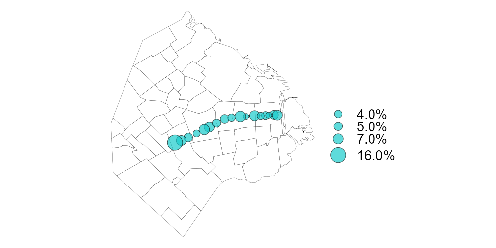

2.81M

14.97%

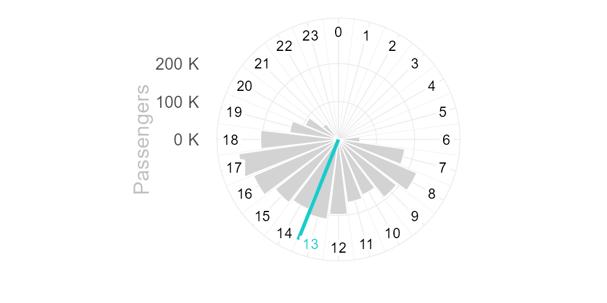

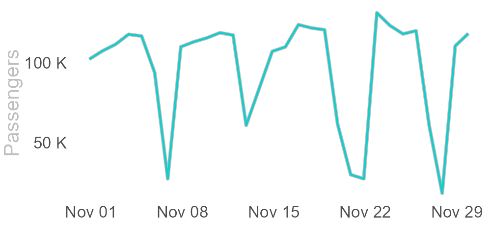

J.M. Rosas - L.N. Alem

Federico Lacroze

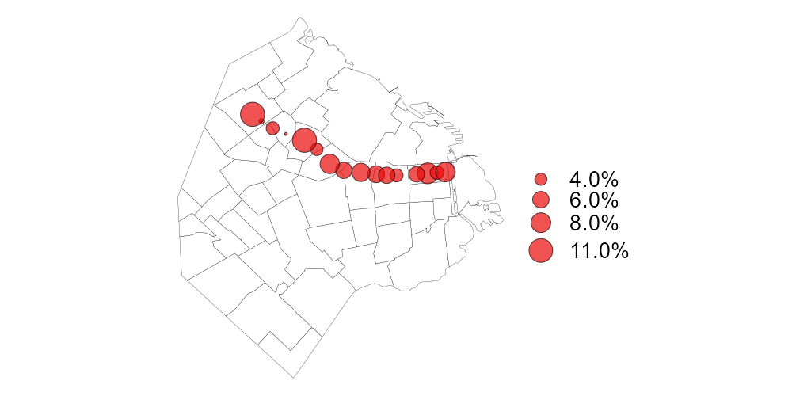

3.48M

12.53%

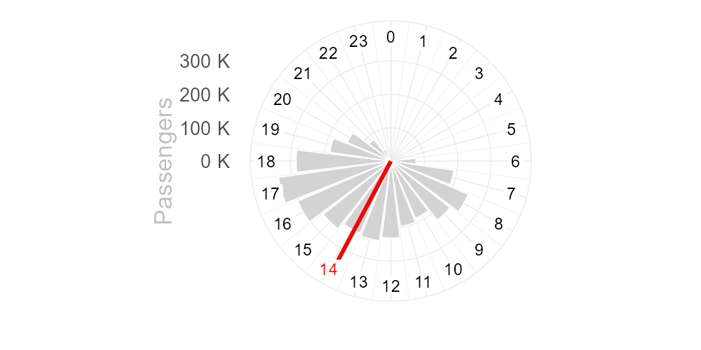

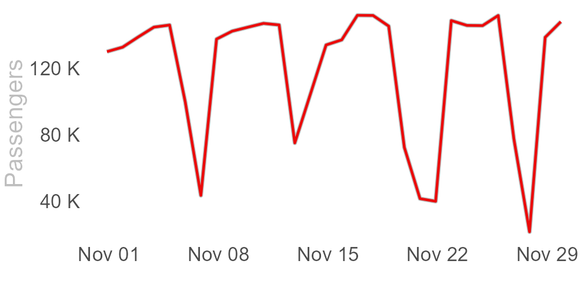

Constitución - Retiro

Constitucion

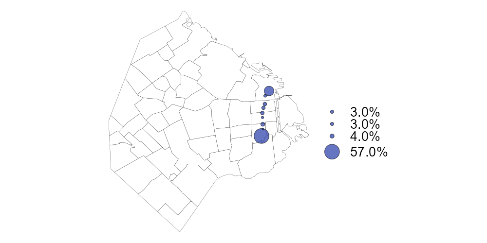

2.13M

19.51%

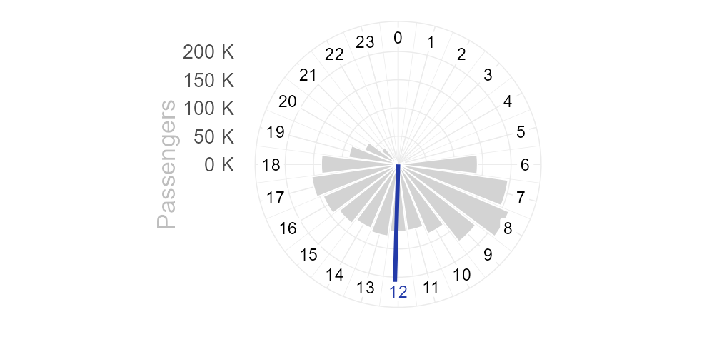

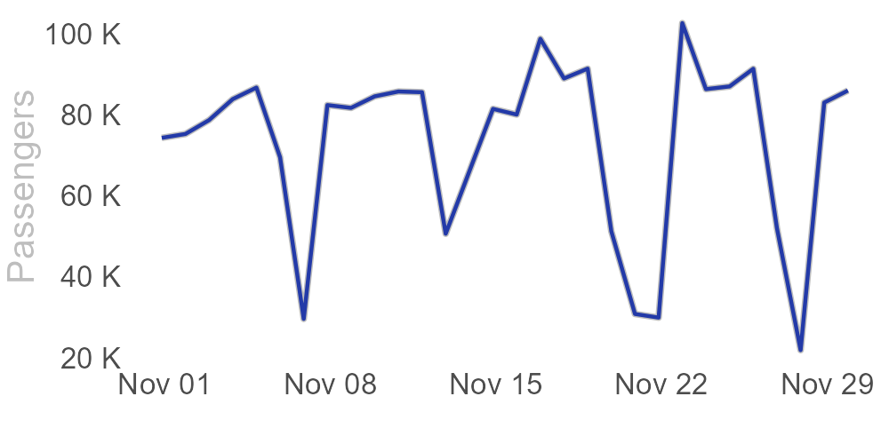

Congreso de Tucumán - Catedral

Congreso de Tucuman

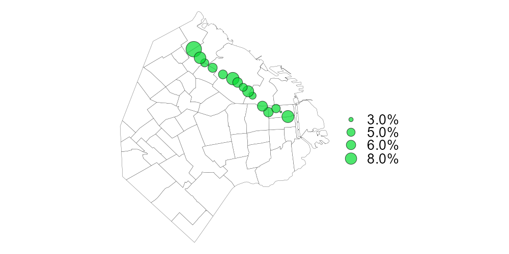

3.00M

11.58%

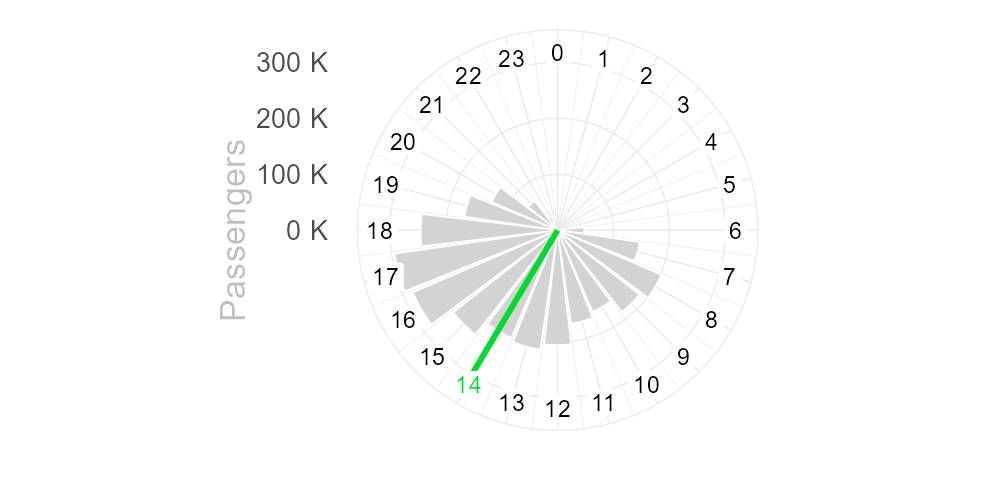

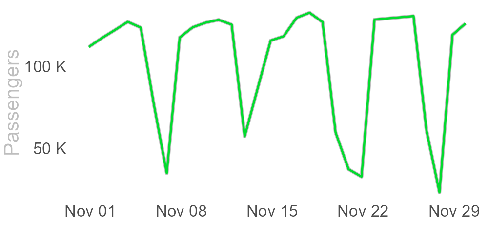

Retiro - Plaza de los Virreyes

Bolivar

[6 more figures not shown]

Own elaboration based on data from the Open Data Portal from the city of Buenos Aires

<sup>1</sup> % of passengers per station in relation to the total number of passengers on that line. For the cuts, the quantiles of the distribution were used. It is observed that Line C presented a very high use in the headwaters, while in the rest of the lines the use was more distributed.

<sup>2</sup> % Variation in relation to October 2021.

<sup>3</sup> Percentage per line: Morning = 5 a 11 hs, Afternoon = 12 a 17 hs, Night = 18 a 23 hs

<sup>4</sup> The color line represents the mean hour, considering the circular distribution of the hour variable.

```r
gt_table <- r_table_data %>%

  gt() %>%

  tab_header(
    title = md(paste0('**',py$title,'**')),
    subtitle = py$subtitle
  ) %>%

  # Estilo
  tab_style(locations = cells_title(groups = 'title'),
    style = list(
      cell_text(
        font = google_font(name = 'Raleway'),
        size = 'xx-large', weight = 'bold', align = 'left', color  = 'darkblue'
      )
    )) %>%

  tab_style(locations = cells_title(groups = 'subtitle'),
  style = list(
    cell_text(
      font  = google_font(name = 'Raleway'),
      size  = 'medium', align = 'left', color = '#666666'
    )
  )) %>%

  opt_align_table_header('left') %>%
  cols_align('center',
    columns = c(
      'pax_total','variation','most_used_station',
      'clock_plot', 'passengers_per_day')
  ) %>%

  cols_width(
    line ~ px(50),
    Route ~ px(100),
    most_used_station ~ px(80),
    clock_plot ~ px(20),
    pax_total ~ px(80),
    variation ~ px(100)
  ) %>%

  # Grouping columns
  tab_spanner(label = "Use per hour",
              columns = c(passengers_type, clock_plot)) %>%

  tab_spanner(label= "Number of passengers",
              columns = c(pax_total, variation)) %>%

   # Colors
  tab_style(
    style = cell_text(color = "#18cccc"),
    locations = cells_body(columns = c(Route), rows = line == 'A')
  ) %>%
  tab_style(
    style = cell_text(color = "#eb0909"),
    locations = cells_body(columns = c(Route), rows = line == 'B')
  ) %>%
  tab_style(
    style = cell_text(color = "#233aa8"),
    locations = cells_body(columns = c(Route), rows = line == 'C')
  ) %>%
  tab_style(
    style = cell_text(color = "#02db2e"),
    locations = cells_body(columns = c(Route), rows = line == 'D')
  ) %>%
  tab_style(
    style = cell_text(color = "#c618cc"),
    locations = cells_body(columns = c(Route), rows = line == 'E')
  ) %>%
  tab_style(
    style = cell_text(color = "#ffdd00"),
    locations = cells_body(columns = c(Route), rows = line == 'H')
  ) %>%
  tab_style(style     = list(cell_fill(color = "#f0f0f0")),
            locations = cells_body(columns = c('Route'))) %>%

   # Format numeric columns
  fmt_number(pax_total, suffixing = TRUE) %>%
  fmt_percent(variation) %>%

  # Mappings:
  text_transform(
    locations = cells_body(columns = c(line)),
    fn = function(line) {
      lapply(here::here('', paste0('images/', tolower(line), '.jpg')),
             local_image, height = 25)
    }
  ) %>%
  cols_label(line = '') %>%

  gt_plt_bar_stack(
    column = passengers_type,
    position = 'fill',
    labels = c("Morning","Afternoon","Night"),
    palette = c('grey', '#A3B1C9','#4C699E'),
    fmt_fn = scales::label_percent(scale=1),
    width = 60) %>%

  text_transform(
    locations = cells_body(columns = clock_plot),
    fn = function(x) {
      map(r_table_data$clock_plot,
        gt::ggplot_image,
        height = px(250),
        aspect_ratio = 2)
    }
  ) %>%

  text_transform(
    locations = cells_body(columns = passengers_per_day),
    fn = function(x) {
      map(r_table_data$passengers_per_day,
        gt::ggplot_image,
        height = px(200),
        aspect_ratio = 2)
    }
  ) %>%

  text_transform(
    locations = cells_body(columns = Map),
    fn = function(x) {
      map(r_table_data$Map,
        gt::ggplot_image,
        height = px(250),
        aspect_ratio = 2)
    }
  ) %>%

  # Naming variables
  cols_label(
    Map = md('% Passengers per station'),
    clock_plot = md('Passengers per hour'),
    pax_total = md('Total'),
    variation = md('% Variation'),
    passengers_per_day = md('Passengers per day'),
    most_used_station = md('Most used station')
  ) %>%


  tab_footnote(cells_column_labels(columns = variation),
               footnote = py$footer_variation) %>%

  tab_footnote(cells_column_labels(columns = clock_plot),
               footnote = py$footer_clock) %>%

  tab_footnote(cells_column_labels(columns = Map),
               footnote = py$footer_map) %>%

  tab_footnote(cells_column_labels(columns = passengers_type),
               footnote = py$footer_moments_day) %>%

  tab_source_note(
    source_note = html(py$source)
  ) %>%


  tab_style(locations = cells_source_notes(),
            style = list(cell_text(
              font  = google_font(name = 'Raleway'),
              size  = 'medium', align = 'left',  color = '#666666'
            ))) %>%

  tab_style(locations = cells_footnotes(),
            style   = list(cell_text(
              font  = google_font(name = 'Raleway'),
              size  = 'medium', align = 'left',  color = '#666666'
            ))) %>%

  tab_options(
    data_row.padding = px(0),
    table.border.top.style = "hidden",
    table.border.bottom.style = "hidden",
    table_body.border.top.style = "solid",
    column_labels.border.bottom.style = "solid"
  ) %>%

  cols_hide('color')

gt_table
```

**Python**

A summary of the use of the subway in the city of Buenos Aires, Argentina

Analysis period: November 2021

Route

Most used station

% Passengers per station (1)

Number of  
passengers

% Variation (2)

% Passengers per moment (3)  
Morning | Afternoon | Night

Passengers per hour (4)

Passengers per day

Plaza de Mayo - San Pedrito

San Pedrito

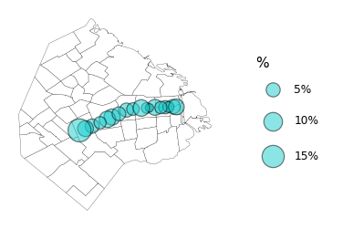

2.81M

14.97%

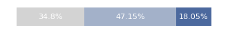

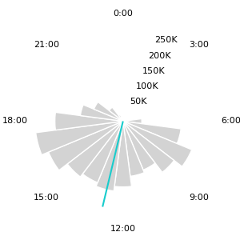

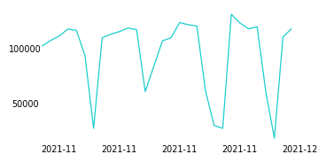

J.M. Rosas - L.N. Alem

Federico Lacroze

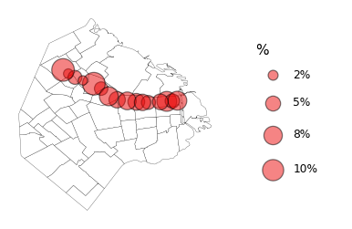

3.48M

12.53%

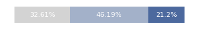

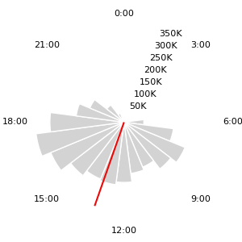

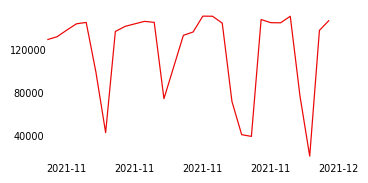

Constitución - Retiro

Constitucion

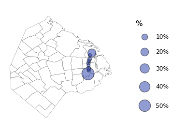

2.13M

19.51%

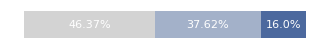

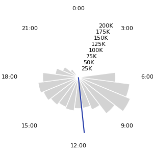

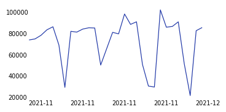

Congreso de Tucumán - Catedral

Congreso de Tucuman

[12 more figures not shown]

(1) % of passengers per station in relation to the total number of passengers on that line. For the cuts, the quantiles of the distribution were used. It is observed that Line C presented a very high use in the headwaters, while in the rest of the lines the use was more distributed.  
(2) % Variation in relation to October 2021.  
(3) Percentage per line: Morning = 5 a 11 hs, Afternoon = 12 a 17 hs, Night = 18 a 23 hs  
(4) The color line represents the mean hour, considering the circular distribution of the hour variable.  
Own elaboration based on data from the Open Data Portal from the city of Buenos Aires

```python
pd_table = (py_table_data.drop('color',axis=1)

  .style

  .applymap(lambda v: f"color: {color_mapping.get(v, 'black')}")

  .applymap(lambda v: f"background-color: {color_mapping_back.get(v, 'white')}")

  .set_table_styles(custom_style)

  .set_caption(f"""
    <h1><span style="color: darkblue">{title}</span><br></h1>
    <span style="color: black">{subtitle}</span><br><br>
    """
   )

  .hide(axis='index')

  # Mappings:
  .format(
    formatter={
      'line':map_line_img,
      'Map':map_plot_mapa,
      'passengers_per_day': map_plot_evol,
      'passengers_type':map_plot_percent,
      'clock_plot': map_plot_clock,
      'variation': '{:,.2%}'.format
    }
  )

  .set_properties(**{'font-size': '18pt'}, overwrite=False)
  .set_properties(subset=['Route'], **{'width': '10px'}, overwrite=False)
  .set_properties(subset=['line'], **{'width': '5px'}, overwrite=False)

  .to_html()

  .replace('line</th>','')
  .replace('pax_total</th>','Number of<br>passengers')
  .replace('passengers_type</th>',
   """% Passengers per moment (3)<br>
      <span style="color: lightgrey">Morning</span> |
      <span style="color: #A3B1C9">Afternoon</span> |
      <span style="color: #4C699E">Night</span>
   """
  )
  .replace('Map</th>','% Passengers per station (1)')
  .replace('variation</th>','% Variation (2)')
  .replace('passengers_per_day</th>','Passengers per day')
  .replace('clock_plot</th>','Passengers per hour (4)')
  .replace('most_used_station</th>','Most used station')
   + f"""<caption>
            (1) {footer_map}
            <br>(2) {footer_variation}
            <br>(3) {footer_moments_day}
            <br>(4) {footer_clock}
            <br>{source}
         </caption>"""
)

# Displaying the table
HTML(pd_table)
```

# Saving the table

Both tables are saved as a png image.

**R**

```r
gt::gtsave(gt_table, 'gt_table.png', vwidth = 2400, vheight = 1000)
```

[figure not shown]

```r
# gt::gtsave(data=gt_table, filename='gt_table.html')
# webshot(
#   url='gt_table.html',
#   file="gt_table2.png",
#    vwidth = 2000, vheight = 1500, cliprect = "viewport"
# )
```

**python**

```python
f = open("pd_table.html", "w")
f.write(pd_table)
```

```
546788
```

```python
f.close()
```

In this case, I’ve decided to use **{webshot2}**, an R package to convert an html file to png:

```r
webshot2::webshot(
  url='pd_table.html',
  file="pd_table.png",
  vwidth=2000,
  vheight = 2200,
  cliprect = "viewport"
)
```

[figure not shown]

## Contact ✉

Karina Bartolome, [Linkedin](https://www.linkedin.com/in/karinabartolome/), [Twitter](https://twitter.com/karbartolome), [Github](https://github.com/karbartolome), [Blogpost](https://karbartolome-blog.netlify.app/)

## References

Iannone, Richard, Joe Cheng, and Barret Schloerke. 2021. *Gt: Easily Create Presentation-Ready Display Tables*. https://CRAN.R-project.org/package=gt.

McKinney, Wes et al. 2010. “Data Structures for Statistical Computing in Python.” In *Proceedings of the 9th Python in Science Conference*, 445:51–56. Austin, TX.

Wickham, Hadley. 2016. *Ggplot2: Elegant Graphics for Data Analysis*. Springer-Verlag New York. https://ggplot2.tidyverse.org.

## Footnotes

[^1]: Wickham (2016)
[^2]: Iannone, Cheng, and Schloerke (2021)
[^3]: McKinney et al. (2010)